# Logistic Regression and Classification

Lakshmi Prasanna Challa

2025-02-27

# 1. INTRODUCTION

Logistic Regression (binary), Multiple Logistic Regression, and Multinomial Logistic Regression.These models will be used to predict categorical outputs like credit default or sales categories.

# 2. Data

Load and inspect the dataset structure. We are using here the ‘Default’ dataset to understand credit default behavior.

```r
data = Default
str(data)
```

```
## 'data.frame':    10000 obs. of  4 variables:
##  $ default: Factor w/ 2 levels "No","Yes": 1 1 1 1 1 1 1 1 1 1 ...
##  $ student: Factor w/ 2 levels "No","Yes": 1 2 1 1 1 2 1 2 1 1 ...
##  $ balance: num  730 817 1074 529 786 ...
##  $ income : num  44362 12106 31767 35704 38463 ...
```

## 2.1 Visualizing the data

### 2.1.1 Distribution of Balance

This histogram shows the distribution of credit card balance and its relation to default status. We expect balances on the higher side to have a greater likelihood of default.

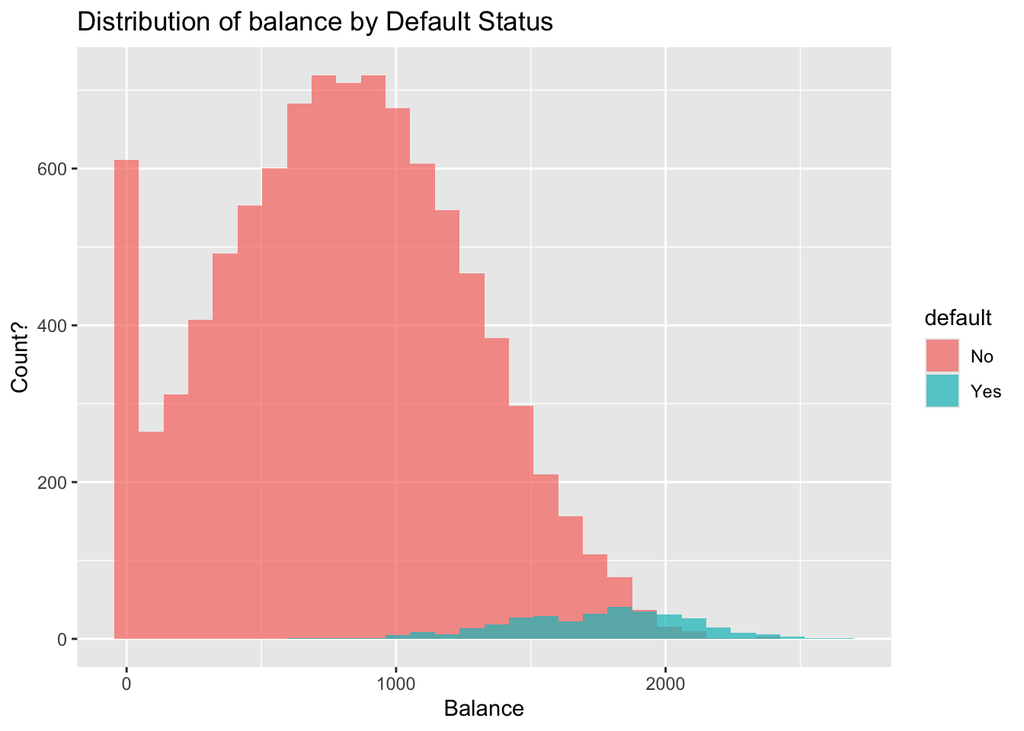

```r
ggplot(data, aes(x =balance, fill=default)) +
  geom_histogram(bins = 30, alpha = 0.7, position = 'identity' ) +
  labs(title = "Distribution of balance by Default Status",
       x = "Balance",
       y = "Count?")
```

### 2.1.2 Distribution of Income

This plot shows income distribution based on default status. It helps establish whether income has any role in predicting default.

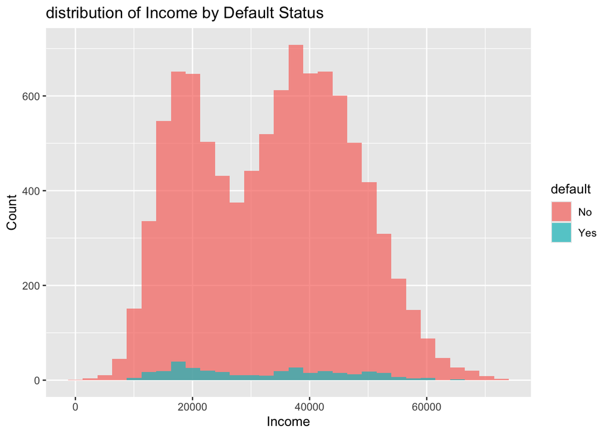

```r
ggplot(data, aes(x = income, fill = default)) +
  geom_histogram(bins = 30, alpha = 0.7, position = 'identity') +
  labs(title = "distribution of Income by Default Status",
       x = "Income",
       y = "Count")
```

[figure not shown]

```r
ggplot(data, aes(x = income, fill = student)) +
  geom_histogram(bins = 30, alpha = 0.7, position = 'identity') +
  labs(title = "distribution of Income by Default Status",
       x = "Income",
       y = "Count")
```

### 2.1.3 Student Status by Default

A bar chart that contrasts the number of defaulting students and non-students. It can be utilized to identify if student status is associated with higher risk of default.

[figure not shown]

```r
ggplot(data, aes(x = student, fill = default)) +
  geom_bar(position ='dodge') +
  labs(title = "distribution of Income by Student Status",
       x = "Student",
       y = "Count")
```

# 4. Logistic Regression

### 4.1 Fitting the Model

Logistic regression is a classification algorithm that can be utilized to forecast the probability of a binary event. Here, we are using it for default status prediction solely on the basis of the balance factor.

```r
logit_model = glm(default ~ balance, data = data, family = binomial)
summary(logit_model)
```

```
##
## Call:
## glm(formula = default ~ balance, family = binomial, data = data)
##
## Coefficients:
##               Estimate Std. Error z value Pr(>|z|)
## (Intercept) -1.065e+01  3.612e-01  -29.49   <2e-16 ***
## balance      5.499e-03  2.204e-04   24.95   <2e-16 ***
## ---
## Signif. codes:  0 '***' 0.001 '**' 0.01 '*' 0.05 '.' 0.1 ' ' 1
##
## (Dispersion parameter for binomial family taken to be 1)
##
##     Null deviance: 2920.6  on 9999  degrees of freedom
## Residual deviance: 1596.5  on 9998  degrees of freedom
## AIC: 1600.5
##
## Number of Fisher Scoring iterations: 8
```

```r
data$predicted_prob = predict(logit_model, type = "response")
head(data)
```

```
##   default student   balance    income predicted_prob
## 1      No      No  729.5265 44361.625   0.0013056797
## 2      No     Yes  817.1804 12106.135   0.0021125949
## 3      No      No 1073.5492 31767.139   0.0085947405
## 4      No      No  529.2506 35704.494   0.0004344368
## 5      No      No  785.6559 38463.496   0.0017769574
## 6      No     Yes  919.5885  7491.559   0.0037041528
```

### 4.2 Evaluate Model Performance

Converts the probabilities to binary predictions by applying a threshold value (defaulted as 0.5) and evaluates the model on confusion matrix and overall accuracy.

```r
threshold = 0.5
data$predicted_default = ifelse(data$predicted_prob > threshold, "yes", "No")
conf_matrix = table(data$predicted_default, data$default)
conf_matrix
```

```
##
##         No  Yes
##   No  9625  233
##   yes   42  100
```

```r
accuracy = sum(diag(conf_matrix)) / sum(conf_matrix)
accuracy
```

```
## [1] 0.9725
```

# 5. Multiple Logistic Regression

## 5.1 Fitting the Model

```r
logit_mult_model = glm(default ~ balance + income * student, data=data,
family=binomial)
summary(logit_mult_model)
```

```
##
## Call:
## glm(formula = default ~ balance + income * student, family = binomial,
##     data = data)
##
## Coefficients:
##                     Estimate Std. Error z value Pr(>|z|)
## (Intercept)       -1.081e+01  5.031e-01 -21.495   <2e-16 ***
## balance            5.737e-03  2.319e-04  24.736   <2e-16 ***
## income             1.644e-06  8.633e-06   0.190    0.849
## studentYes        -9.343e-01  6.067e-01  -1.540    0.124
## income:studentYes  1.429e-05  2.772e-05   0.516    0.606
## ---
## Signif. codes:  0 '***' 0.001 '**' 0.01 '*' 0.05 '.' 0.1 ' ' 1
##
## (Dispersion parameter for binomial family taken to be 1)
##
##     Null deviance: 2920.6  on 9999  degrees of freedom
## Residual deviance: 1571.3  on 9995  degrees of freedom
## AIC: 1581.3
##
## Number of Fisher Scoring iterations: 8
```

## 5.2 Evaluating the Model

Use the trained multiple logistic regression model to make default predictions and evaluate the model based on confusion matrix and accuracy.

```r
data$mult_predicted_prob = predict(logit_mult_model, type = "response")
data$mult_predicted_default = ifelse(data$mult_predicted_prob > threshold, "Yes", "No")
conf_matrix_mult = table(data$mult_predicted_default, data$default)
conf_matrix_mult
```

```
##
##         No  Yes
##   No  9628  227
##   Yes   39  106
```

```r
accuracy_mult = sum(diag(conf_matrix_mult)) / sum(conf_matrix_mult)
accuracy_mult
```

```
## [1] 0.9734
```

# 6. Multinomial Logistic Regression

## 6.1 Load the Data

Import Carseats dataset and create a new categorical variable ‘SalesCategory’ by categorizing Sales as Low, Medium, High classes.

```r
data2 = Carseats
data2$SalesCategory = cut(data2$Sales, breaks = 3, labels = c("Low", "Medium", "High"))
```

```r
multi_model = multinom(SalesCategory ~ Price + Income +Advertising,
data = data2)
summary(multi_model)
```

```
## Call:
## multinom(formula = SalesCategory ~ Price + Income + Advertising,
##     data = data2)
##
## Coefficients:
##        (Intercept)       Price      Income Advertising
## Medium    3.645096 -0.02909122 0.004288951   0.0834958
## High      4.839031 -0.06414212 0.011164722   0.1417921
##
## Std. Errors:
##        (Intercept)       Price      Income Advertising
## Medium   0.7937487 0.006004112 0.004488935  0.02137942
## High     1.1240727 0.009264365 0.006892574  0.03025054
##
## Residual Deviance: 640.794
## AIC: 656.794
```

## 6.2 Make Predictions

Make predictions of the sales category for each record using the multinomial model.

```r
data2$nomial_predicted_salesCat = predict(multi_model)
head(data2)
```

```
##   Sales CompPrice Income Advertising Population Price ShelveLoc Age Education
## 1  9.50       138     73          11        276   120       Bad  42        17
## 2 11.22       111     48          16        260    83      Good  65        10
## 3 10.06       113     35          10        269    80    Medium  59        12
## 4  7.40       117    100           4        466    97    Medium  55        14
## 5  4.15       141     64           3        340   128       Bad  38        13
## 6 10.81       124    113          13        501    72       Bad  78        16
##   Urban  US SalesCategory nomial_predicted_salesCat
## 1   Yes Yes        Medium                    Medium
## 2   Yes Yes          High                    Medium
## 3   Yes Yes        Medium                    Medium
## 4   Yes Yes        Medium                    Medium
## 5   Yes  No           Low                    Medium
## 6    No Yes        Medium                      High
```

## 6.3 Evaluate Model

Evaluate the multinomial model’s performance by analyzing predicted vs actual categories and overall prediction accuracy.

```r
conf_matrix_multi = table(data2$nomial_predicted_salesCat, data2$SalesCategory)
conf_matrix_multi
```

```
##
##          Low Medium High
##   Low     25     17    0
##   Medium  77    224   48
##   High     0      6    3
```

```r
accuracy_multi = sum(diag(conf_matrix_multi)) / sum(conf_matrix_multi)
accuracy_multi
```

```
## [1] 0.63
```

# Background

Diabetes is a chronic disease affecting millions of individuals worldwide. Early detection through predictive modelling can help guide prevention and treatment. in this assignment , you will use logistic regression to predict whether an individual has diabetes using basic health information.

We will use the Pima Indians Diabetes Dataset, a commonly used dataset in health informatics available from the UCI Machine Learning Repository and built into the mlbench R package.

# Simple Logistic Regression

We use logistic regression to predict diabetes presence based on glucose levels. This binary classification model estimates the probability of a person having diabetes, where the glucose level serves as the sole predictor variable. The output is a probability score, with a threshold determining the prediction of either diabetes (1) or no diabetes (0).

```r
library(mlbench)
data(PimaIndiansDiabetes)
df = PimaIndiansDiabetes
```

## Data Exploration and Summary Figures

To explore the data, we create a histogram that visualizes the distribution of glucose levels for individuals, split by diabetes status (positive or negative). This allows us to compare the glucose levels between diabetic and non-diabetic groups, helping identify if there are significant differences in glucose levels. A clear separation or overlap in the distributions can indicate patterns useful for building a predictive model.

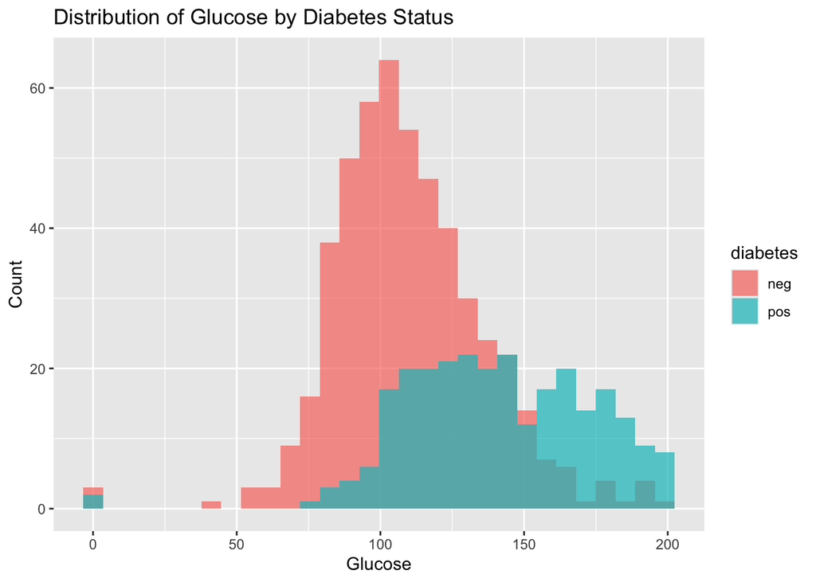

```r
ggplot(PimaIndiansDiabetes, aes(x = glucose, fill = diabetes)) +
  geom_histogram(bins = 30, alpha = 0.7, position = 'identity') +
  labs(title = "Distribution of Glucose by Diabetes Status",
       x = "Glucose",
       y = "Count")
```

## Fit a Simple Logistic Regression Model (Train & Test Split)

We split the Pima Indians Diabetes dataset into 70% training and 30% testing. A logistic regression model is fitted using glucose as the sole predictor with the `glm()` function (binomial family). The model is trained on the training set, and the `summary()` function provides the coefficients and fit details.

```r
set.seed(123)
split = sample(1:nrow(PimaIndiansDiabetes), 0.7 * nrow(PimaIndiansDiabetes))
train = PimaIndiansDiabetes[split, ]
test = PimaIndiansDiabetes[-split, ]

simple_model = glm(diabetes ~ glucose, data = train, family = "binomial")
summary(simple_model)
```

```
##
## Call:
## glm(formula = diabetes ~ glucose, family = "binomial", data = train)
##
## Coefficients:
##              Estimate Std. Error z value Pr(>|z|)
## (Intercept) -5.480896   0.517598 -10.589   <2e-16 ***
## glucose      0.038630   0.003976   9.716   <2e-16 ***
## ---
## Signif. codes:  0 '***' 0.001 '**' 0.01 '*' 0.05 '.' 0.1 ' ' 1
##
## (Dispersion parameter for binomial family taken to be 1)
##
##     Null deviance: 694.17  on 536  degrees of freedom
## Residual deviance: 563.72  on 535  degrees of freedom
## AIC: 567.72
##
## Number of Fisher Scoring iterations: 4
```

## Interpret Coefficients & Apply the Model for Prediction on the test Data

We apply the trained logistic regression model to the test set using the `predict()` function to generate predicted probabilities. These probabilities are converted into binary outcomes (“pos” for positive diabetes, “neg” for negative diabetes) with a 0.5 threshold. We then use the `table()` function to create a confusion matrix, comparing the predicted labels with the actual test labels, allowing us to assess the model’s performance on new data.

```r
preds_test = ifelse(predict(simple_model, newdata = test, type = "response") > 0.5, "pos", "neg")
table(Predicted = preds_test, Actual = test$diabetes)
```

```
##          Actual
## Predicted neg pos
##       neg 131  44
##       pos  19  37
```

# Multiple Logistic Regression

## Fit a Multiple Logistic Regression `model (Train & Test Split)

We enhance the logistic regression model by incorporating multiple predictors—glucose, BMI, age, and blood pressure—to predict diabetes likelihood. The `glm()` function with a binomial family is applied to the training data, and the `summary()` function provides coefficients, showing the impact of each variable on diabetes probability.

```r
multi_model = glm(diabetes ~ glucose + mass + age + pressure, data = train, family = "binomial")
summary(multi_model)
```

```
##
## Call:
## glm(formula = diabetes ~ glucose + mass + age + pressure, family = "binomial",
##     data = train)
##
## Coefficients:
##              Estimate Std. Error z value Pr(>|z|)
## (Intercept) -8.018594   0.800361 -10.019  < 2e-16 ***
## glucose      0.032892   0.004085   8.051 8.21e-16 ***
## mass         0.088657   0.016801   5.277 1.32e-07 ***
## age          0.034179   0.009364   3.650 0.000262 ***
## pressure    -0.011695   0.005870  -1.992 0.046317 *
## ---
## Signif. codes:  0 '***' 0.001 '**' 0.01 '*' 0.05 '.' 0.1 ' ' 1
##
## (Dispersion parameter for binomial family taken to be 1)
##
##     Null deviance: 694.17  on 536  degrees of freedom
## Residual deviance: 523.86  on 532  degrees of freedom
## AIC: 533.86
##
## Number of Fisher Scoring iterations: 4
```

```r
preds_test = ifelse(predict(simple_model, newdata = test, type = "response") > 0.5, "pos", "neg")
table(Predicted = preds_test, Actual = test$diabetes)
```

```
##          Actual
## Predicted neg pos
##       neg 131  44
##       pos  19  37
```

# K-Nearest Neighbors Classification

K-Nearest Neighbors (KNN) is a simple, flexible algorithm that makes predictions based on the majority class of the closes data points.

Use the `caret` and `class` libraries with the `knn()` function. see our in-class lab for a worked example.

## Prepare the Data

```r
library(caret)
library(class)

train_knn = train
test_knn = test

train_X = scale(train_knn[, c("glucose", "mass", "age", "pressure")])
test_X = scale(test_knn[, c("glucose", "mass", "age", "pressure")])

train_y = train_knn$diabetes
test_y = test_knn$diabetes
```

## Fit a KNN Classifies Model (Train & Test Split)

The K-Nearest Neighbors (KNN) algorithm is applied to classify diabetes status using the `knn()` function, with `k = 5` and training data (train_X, train_y). The `table()` function creates a confusion matrix to compare predicted (knn_preds) and actual (test_y) diabetes statuses, allowing evaluation of the model’s accuracy.

```r
set.seed(123)
knn_preds = knn(train = train_X, test = test_X, cl = train_y, k = 5)
table(Predicted = knn_preds, Actual = test_y)
```

```
##          Actual
## Predicted neg pos
##       neg 124  32
##       pos  26  49
```

## Interpret & Apply to Test Data

After fitting the K-Nearest Neighbors (KNN) model to the training data and predicting on the test set, Compute the following performance metrics:

- **Accuracy**: (True Positives + True Negatives) / Total = (124 + 49) / 231 = 0.749 (or 74.9%)
- **Precision (positive class)**: True Positives / (True Positives + False Positives) = 49 / (49 + 26) ≈ 0.653 (or 65.3%)
- **Recall (positive class)**: True Positives / (True Positives + False Negatives) = 49 / (49 + 32) ≈ 0.605 (or 60.5%)

**Interpretation:**

The KNN model achieved 74.9% accuracy, correctly predicting most cases. With a precision of 65.3%, it was accurate 65% of the time when diagnosing diabetes. Its recall of 60.5% means it identified 60% of actual diabetes cases. While performance is solid, the relatively low recall could be problematic in medical settings, where missing a diagnosis is critical.

# Model Comparison and Discussion

In this project, we implemented and evaluated three classification models to predict diabetes:

[output not shown]